# Columbia Sockeye Inseason Forecast for Counts 5/1-12/31 @ Bonneville Dam

Thomas Buehrens (tbuehrens@dfw.wa.gov)

Last Updated 12/07/2022.

# Overview

This script fits Seasonal Auto-Regressive Integrated Moving Average (SARIMA) models to in-season salmon return data to predict total return. It does this by aggregating the run-size into two periods: counts prior to a particular date (often the date of the most recent observation), and counts after that date (i.e., the remainder of the run). It then predicts the remainder of the run using the pattern of abundance before and after that date in previous years, in conjunction with covariates. This software evaluates the model’s skill at predicting the remainder of the runsize based on data collected up to a particular date. A forecast for the final year, including confidence intervals, is produced.

```r
options(width = 100)
knitr::opts_chunk$set(message = FALSE)
set.seed(123)
```

```r
wd_functions<-"functions"
sapply(FUN = source, paste(wd_functions, list.files(wd_functions), sep="/"))
```

```r
packages_list<-c("tidyverse"
                 ,"forecast"
                 ,"mgcv"
                 ,"ggplot2"
                 ,"MASS"
                 ,"RColorBrewer"
                 ,"kableExtra"
                 ,"lubridate"
                 ,"modelr"
                 ,"kableExtra"
                 ,"reshape2"
                 ,"ggfortify"
                 ,"clock"
                 ,"smooth"
                 ,"scales"
                 ,"gtools"
                 ,"CombMSC"
                 ,"here"
                 ,"MuMIn"
                 ,"janitor"
                 ,"rvest"
                 ,"lubridate"
                 )
install_or_load_pack(pack = packages_list)
```

## User Inputs

Look at this section to see user inputs regarding the years and dates of data analyzed and covariates used.

```r
#=========
# Raw Data
#=========
yr_start<-2002
yr_end<-year(Sys.Date())
dam="BON"
species="Sockeye"
#===========================
# Summarization for analysis
#===========================
date_start_analysis<-ymd("2002/1/1") #this will be the first date of data used in the analysis (and this month/day first in years thereafter)
date_end_analysis<-ymd("2023/12/31") #this will be the last date of data used in the analysis (and this month/day last in years preceding)
forecast_period_start_m<-1 #this will be the month associated with the first month/day of the seasonal estimate period each year...can be after first data used to estimate it or the same
forecast_period_start_d<-1 #this will be the month day associated with the first month/day of the seasonal estimate period each year...can be after first data used to estimate it or the same
last_data<-Sys.Date()
#==================
#forecasting params
#==================
leave_yrs<- 11
covariates<-c("pink_ind","lag1_log_SAR1","lag2_NPGO","lag2_PDO","lag1_log_SAR2","lag1_NPGO","lag1_PDO","lag4_log_adults")
plot_results = F
first_forecast_period = 1
write_model_summaries = TRUE
find_best=T
#==============
#Ensemble Params
#===============
min_vars<-1
max_vars<-6
forecast_type<-"preseason"
stack_metric<-"MAPE"
num_models<-20
```

## Get Raw Data

Data is loaded here a a snapshot of the data used in the analysis (before aggregation into the two periods described) is provided.

```r
dat<-read_csv("http://www.cbr.washington.edu/dart/cs/php/rpt/adult_annual.php?sc=1&outputFormat=csv&proj=BON&startdate=5%2F1&enddate=12%2F31")%>%
  arrange(Year)%>%
  dplyr::select(year=Year, Sockeye)%>%
  dplyr::rename(abundance=Sockeye)%>%
  mutate(abundance=ifelse(as.numeric(year)<=as.numeric(format(Sys.Date(),"%Y")),abundance,NA),
         species = "Sockeye"
         )%>%
  filter(!is.na(year))

Yrlist<-data.frame(year=c(min(dat$year):(max(dat$year)+1)))

dat<-dat%>%
  right_join(Yrlist)

#=========================================================
#get PDO data
#=========================================================
PDO<-read_table("https://psl.noaa.gov/pdo/data/pdo.timeseries.ersstv5.csv",skip=1,col_names=F,comment="#")%>%
  dplyr::rename(Date=X1,PDO=X2)%>%
  filter(!PDO < -99)%>%
  mutate(Date=as.Date(Date),Month=month(Date),Year=year(Date))%>%
  group_by(Year)%>%
  add_tally()%>%
  #filter(!Month>6)%>% #use only spring (Jan-June) NPGO
  #filter(!n < 12)%>% #use only complete years
  group_by(Year)%>%
  dplyr::rename(year=Year)%>%
  dplyr::summarise(PDO=mean(PDO))%>%
  right_join(Yrlist)%>%
  mutate(lag2_PDO = lag(PDO,2), lag1_PDO = lag(PDO,1))%>%
  dplyr::select(year,lag2_PDO, lag1_PDO)
#=========================================================
#get NPGO data
#=========================================================
NPGO<-read_table("http://www.o3d.org/npgo/npgo.php",skip=29,col_names=F,comment="#")%>%
  filter(!is.na(X2))%>%
  dplyr::rename(Year=X1,Month=X2,NPGO=X3)%>%
  mutate(Year=as.numeric(Year))%>%
  group_by(Year)%>%
  add_tally()%>%
  #filter(!Month>6)%>% #use only spring (Jan-June) NPGO
  #filter(!n < 12)%>% #use only complete years
  group_by(Year)%>%
  dplyr::summarise(NPGO=mean(NPGO))%>%
  dplyr::rename(year=Year)%>%
  right_join(Yrlist)%>%
  arrange(year)%>%
  mutate(year=year+1, lag1_NPGO = NPGO,lag2_NPGO = lag(NPGO))%>%
  dplyr::select(year,lag1_NPGO,lag2_NPGO)
#=========================================================
#get PIT tag survival/age data
#=========================================================
PIT<-read_html("https://www.cbr.washington.edu/dart/wrapper?type=php&fname=pitsaresu_1670285794_819.csv")%>%
  html_nodes("body")%>%
  html_text()%>%
  read_lines(skip_empty_rows = T)%>%
  tibble()%>%
  setNames("lines")%>%
  filter(grepl("year",lines) | grepl("20",lines) & !grepl("Generated",lines) & !grepl("DART Data Citation",lines))%>%
  as_vector()%>%
  str_split(",")%>%
  as.data.frame()%>%
  as.matrix()%>%
  t()%>%
  as_tibble()%>%
  row_to_names(row_number = 1)%>%
  type.convert()%>%
  filter(year!=year(Sys.Date()))%>%
  mutate(OutmigrationYear=year,Year=OutmigrationYear+2)

PIT<-PIT%>%bind_cols(data.frame(SAR1=gam(cbind(ocean1Count,juvCount-ocean1Count)~s(OutmigrationYear,k=(dim(PIT)[1]),m=1,bs="ps"),family=binomial,data=PIT)$fitted))%>%
  bind_cols(data.frame(SAR2=c(gam(cbind(ocean2Count,juvCount-ocean2Count)~s(OutmigrationYear,k=(dim(PIT)[1]-1),m=1,bs="ps"),family=binomial,data=PIT)$fitted,NA)))%>%
  mutate(lag1_log_SAR1 = log(SAR1),lag1_log_SAR2=lag(log(SAR2),1))%>%
  dplyr::select(year=Year,lag1_log_SAR1,lag1_log_SAR2)
#================================================================
dat<-dat%>%
  left_join(PDO)%>%
  left_join(NPGO)%>%
  left_join(PIT)%>%
  mutate(pink_ind = ifelse(year>1999 & year%%2==0,0,1),
         period=1,
         lag4_log_adults = lag(log(abundance),4)
         )%>%
  ungroup()%>%
  dplyr::select(year,species,period,abundance,all_of(unique(unlist(covariates))))%>%
  filter(
    across(
      .cols = all_of(unique(unlist(covariates))),
      .fns = ~ !is.na(.x)
    )
  )

print(tail(dat))
```

```
## # A tibble: 6 × 12
##    year species period abundance pink_ind lag1_log…¹ lag2_…² lag2_…³ lag1_…⁴ lag1_…⁵ lag1_…⁶ lag4_…⁷
##   <dbl> <chr>    <dbl>     <dbl>    <dbl>      <dbl>   <dbl>   <dbl>   <dbl>   <dbl>   <dbl>   <dbl>
## 1  2018 Sockeye      1    193816        0     -11.0   -0.190  0.633    -5.32  -0.862 -0.0593    13.3
## 2  2019 Sockeye      1     63046        1     -11.4   -0.862 -0.0593   -5.11  -1.91  -0.296     13.1
## 3  2020 Sockeye      1    341739        0     -11.6   -1.91  -0.296    -8.23  -2.25  -0.0288    12.7
## 4  2021 Sockeye      1    151764        1     -11.3   -2.25  -0.0288   -8.69  -1.77  -1.04      11.4
## 5  2022 Sockeye      1    663253        0      -9.73  -1.77  -1.04     -5.41  -0.879 -1.57      12.2
## 6  2023 <NA>         1        NA        1      -7.72  -0.879 -1.57     -4.71  -0.809 -1.76      11.1
## # … with abbreviated variable names ¹lag1_log_SAR1, ²lag2_NPGO, ³lag2_PDO, ⁴lag1_log_SAR2,
## #   ⁵lag1_NPGO, ⁶lag1_PDO, ⁷lag4_log_adults
```

## Results

This section present a a results table showing the performance of the prediction model in previous years as well as a forecast in the current year. The results in the table are graphed below.

```r
if(find_best ==T){
  best_covariates<-all_subsets(series=dat,covariates=covariates,min=min_vars,max=max_vars,type=forecast_type)
  saveRDS(best_covariates,"best_covariates_sockeye_preseason.rds")
}
```

[output not shown]

[output cut: 232 more lines]

```r
# results<-inseason_forecast(series=summarized_data$series,
#                   leave_yrs=leave_yrs,
#                   covariates= c("lag2_NPGO","lag1_log_SAR2","lag2_log_smolts","var_flow","zl_flow"), #use to automate variable selection: best_covariates[[1]][[best_covariates[[2]]$model_num[1]]],
#                   first_forecast_period = first_forecast_period,
#                   plot_results = plot_results,
#                   write_model_summaries = write_model_summaries,
#                   forecast_period_start_m =  forecast_period_start_m, #inclusive
#                   forecast_period_start_d =  forecast_period_start_d, #inclusive
#                   obs_period_2 = summarized_data$obs_period_2,
#                   p1_covariates_only = p1_covariates_only
#                   )

best_covariates<-readRDS("best_covariates_sockeye_preseason.rds")

best_covariates[[2]]%>%
  slice(1:num_models)%>%
  kbl(caption = "Table 1. Covariate Model Selection Results.",digits =3)%>%
  kable_classic(full_width = F, html_font = "Cambria")
```

Table 1. Covariate Model Selection Results.

| model_num | AICc | formula |
| --- | --- | --- |
| 105 | 34.556 | abundance ~ pink_ind + lag1_log_SAR1 + lag1_NPGO + lag1_PDO |
| 9 | 34.859 | abundance ~ pink_ind + lag1_log_SAR1 |
| 40 | 35.201 | abundance ~ pink_ind + lag1_log_SAR1 + lag1_NPGO |
| 41 | 36.541 | abundance ~ pink_ind + lag1_log_SAR1 + lag1_PDO |
| 2 | 37.317 | abundance ~ lag1_log_SAR1 |
| 13 | 37.977 | abundance ~ pink_ind + lag1_NPGO |
| 38 | 38.174 | abundance ~ pink_ind + lag1_log_SAR1 + lag2_PDO |
| 42 | 38.297 | abundance ~ pink_ind + lag1_log_SAR1 + lag4_log_adults |
| 37 | 38.337 | abundance ~ pink_ind + lag1_log_SAR1 + lag2_NPGO |
| 176 | 38.954 | abundance ~ pink_ind + lag1_log_SAR1 + lag2_PDO + lag1_NPGO + lag1_PDO |
| 170 | 39.176 | abundance ~ pink_ind + lag1_log_SAR1 + lag2_NPGO + lag1_NPGO + lag1_PDO |
| 99 | 39.211 | abundance ~ pink_ind + lag1_log_SAR1 + lag2_PDO + lag1_NPGO |
| 106 | 39.258 | abundance ~ pink_ind + lag1_log_SAR1 + lag1_NPGO + lag4_log_adults |
| 95 | 39.314 | abundance ~ pink_ind + lag1_log_SAR1 + lag2_NPGO + lag1_NPGO |
| 100 | 40.216 | abundance ~ pink_ind + lag1_log_SAR1 + lag2_PDO + lag1_PDO |
| 16 | 40.244 | abundance ~ lag1_log_SAR1 + lag2_NPGO |
| 96 | 40.378 | abundance ~ pink_ind + lag1_log_SAR1 + lag2_NPGO + lag1_PDO |
| 20 | 40.540 | abundance ~ lag1_log_SAR1 + lag1_PDO |
| 55 | 40.676 | abundance ~ pink_ind + lag1_NPGO + lag1_PDO |
| 45 | 40.742 | abundance ~ pink_ind + lag2_NPGO + lag1_NPGO |

```r
results<-preseason_forecast(series=dat,
                  leave_yrs=leave_yrs,
                  covariates= best_covariates[[1]][best_covariates[[2]]$model_num[1:num_models]],
                  first_forecast_period = first_forecast_period,
                  plot_results = plot_results,
                  write_model_summaries = write_model_summaries,
                  forecast_period_start_m =  forecast_period_start_m, #inclusive
                  forecast_period_start_d =  forecast_period_start_d, #inclusive
                  stack_metric = stack_metric
                  )

model_list<-lapply(best_covariates[[1]][best_covariates[[2]]$model_num[1:num_models]],function(x) paste(x,collapse = " + "))%>%
  unlist()%>%
  as_tibble()%>%
  add_rownames()%>%
  dplyr::rename(model=rowname,model_name=value)

results%>%
  filter(year==max(year))%>%
  left_join(model_list)%>%
  dplyr::select(year,model_name,predicted_abundance,`Lo 50`,`Hi 50`,`Lo 95`,`Hi 95`,Stacking_weight)%>%
  kbl(caption = paste0("Table 2.Individual ensemble member predictions from the best ",num_models," models. These models were used to develop an ensemble using stacking weights which were optimized based on one-year-ahead performance over ",leave_yrs-1," years using ",stack_metric,". Optimized stacking weights are shown."),digits =2)%>%
  kable_classic(full_width = F, html_font = "Cambria")
```

Table 2.Individual ensemble member predictions from the best 20 models. These models were used to develop an ensemble using stacking weights which were optimized based on one-year-ahead performance over 10 years using MAPE. Optimized stacking weights are shown.

| year | model_name | predicted_abundance | Lo 50 | Hi 50 | Lo 95 | Hi 95 | Stacking_weight |
| --- | --- | --- | --- | --- | --- | --- | --- |
| 2023 | pink_ind + lag1_log_SAR1 + lag1_NPGO + lag1_PDO | 476206.5 | 343269.2 | 660626.2 | 183949.55 | 1232798.1 | 0.00 |
| 2023 | pink_ind + lag1_log_SAR1 | 605037.3 | 411875.2 | 888789.2 | 197905.35 | 1849723.5 | 0.00 |
| 2023 | pink_ind + lag1_log_SAR1 + lag1_NPGO | 468042.7 | 325599.5 | 672802.0 | 163049.27 | 1343544.8 | 0.00 |
| 2023 | pink_ind + lag1_log_SAR1 + lag1_PDO | 647144.9 | 443675.5 | 943925.1 | 216086.93 | 1938092.5 | 0.00 |
| 2023 | lag1_log_SAR1 | 873245.9 | 594811.8 | 1282016.4 | 286131.84 | 2665059.8 | 0.00 |
| 2023 | pink_ind + lag1_NPGO | 248757.0 | 163201.2 | 379164.2 | 73089.40 | 846635.2 | 0.00 |
| 2023 | pink_ind + lag1_log_SAR1 + lag2_PDO | 629547.2 | 423665.6 | 935477.7 | 199162.59 | 1989980.8 | 0.00 |
| 2023 | pink_ind + lag1_log_SAR1 + lag4_log_adults | 633934.1 | 426007.6 | 943345.7 | 199717.97 | 2012199.7 | 0.00 |
| 2023 | pink_ind + lag1_log_SAR1 + lag2_NPGO | 613126.6 | 411832.8 | 912808.0 | 192901.14 | 1948792.4 | 0.53 |
| 2023 | pink_ind + lag1_log_SAR1 + lag2_PDO + lag1_NPGO + lag1_PDO | 507230.2 | 362744.2 | 709266.9 | 191469.88 | 1343723.1 | 0.00 |
| 2023 | pink_ind + lag1_log_SAR1 + lag2_NPGO + lag1_NPGO + lag1_PDO | 511831.6 | 365234.0 | 717270.3 | 191981.04 | 1364569.9 | 0.26 |
| 2023 | pink_ind + lag1_log_SAR1 + lag2_PDO + lag1_NPGO | 483373.3 | 332098.5 | 703555.5 | 162399.26 | 1438736.6 | 0.00 |
| 2023 | pink_ind + lag1_log_SAR1 + lag1_NPGO + lag4_log_adults | 491087.4 | 337220.5 | 715160.7 | 164738.17 | 1463940.3 | 0.00 |
| 2023 | pink_ind + lag1_log_SAR1 + lag2_NPGO + lag1_NPGO | 462436.9 | 317349.6 | 673855.9 | 154847.51 | 1381022.5 | 0.00 |
| 2023 | pink_ind + lag1_log_SAR1 + lag2_PDO + lag1_PDO | 691477.0 | 469750.8 | 1017859.9 | 224831.05 | 2126665.8 | 0.00 |
| 2023 | lag1_log_SAR1 + lag2_NPGO | 950601.5 | 646467.3 | 1397817.3 | 310033.66 | 2914661.7 | 0.00 |
| 2023 | pink_ind + lag1_log_SAR1 + lag2_NPGO + lag1_PDO | 700248.8 | 474834.3 | 1032672.6 | 226467.66 | 2165202.8 | 0.00 |
| 2023 | lag1_log_SAR1 + lag1_PDO | 890244.1 | 604465.2 | 1311133.6 | 289018.92 | 2742154.6 | 0.00 |
| 2023 | pink_ind + lag1_NPGO + lag1_PDO | 232223.4 | 151624.5 | 355666.0 | 67286.45 | 801464.4 | 0.00 |
| 2023 | pink_ind + lag2_NPGO + lag1_NPGO | 310020.2 | 202251.0 | 475214.2 | 89610.16 | 1072562.9 | 0.21 |
| 2023 | NA | 524182.9 | 356496.5 | 771438.8 | 171426.20 | 1615061.7 | NA |

```r
if(length(unique(results$model))>1){

  results_best<-results%>%
  ungroup()%>%
  filter(model =="ensemble")%>%
  dplyr::select(-period)
}



results_best%>%
  dplyr::select(!c("train_test"))%>%
  kbl(caption = paste0("Table 3. One-year-ahead forecasts of ",dam," dam counts of ",species,". Additional covariates are included in the table below."),digits =2)%>%
  kable_classic(full_width = F, html_font = "Cambria")
```

Table 3. One-year-ahead forecasts of BON dam counts of Sockeye. Additional covariates are included in the table below.

| year | species | abundance | pink_ind | lag1_log_SAR1 | lag1_NPGO | lag1_PDO | lag2_PDO | lag4_log_adults | lag2_NPGO | predicted_abundance | Lo 50 | Hi 50 | Lo 95 | Hi 95 | error | pct_error | model | Stacking_weight |
| --- | --- | --- | --- | --- | --- | --- | --- | --- | --- | --- | --- | --- | --- | --- | --- | --- | --- | --- |
| 2013 | Sockeye | 185505 | 1 | -5.86 | 1.48 | -1.41 | -1.57 | 12.09 | 0.86 | 185674.00 | 146277.69 | 241748.58 | 98944.72 | 429552.9 | 169.00 | 0% | ensemble | NA |
| 2014 | Sockeye | 614175 | 0 | -5.11 | 0.35 | -0.93 | -1.41 | 12.86 | 1.48 | 420196.77 | 318326.93 | 564354.15 | 197613.77 | 1032025.9 | -193978.23 | -32% | ensemble | NA |
| 2015 | Sockeye | 510705 | 1 | -5.68 | -0.25 | 0.53 | -0.93 | 12.13 | 0.35 | 103115.07 | 75420.60 | 141380.26 | 41906.16 | 259881.4 | -407589.93 | -80% | ensemble | NA |
| 2016 | Sockeye | 342497 | 0 | -7.55 | -1.39 | 0.80 | 0.53 | 13.15 | -0.25 | 257299.14 | 181251.38 | 370165.56 | 96692.14 | 765261.7 | -85197.86 | -25% | ensemble | NA |
| 2017 | Sockeye | 87693 | 1 | -9.96 | -0.19 | 0.63 | 0.80 | 12.13 | -1.39 | 97838.37 | 66708.03 | 144708.45 | 33070.51 | 310874.6 | 10145.37 | 12% | ensemble | NA |
| 2018 | Sockeye | 193816 | 0 | -11.02 | -0.86 | -0.06 | 0.63 | 13.33 | -0.19 | 139953.16 | 95294.46 | 206797.59 | 46767.43 | 441177.9 | -53862.84 | -28% | ensemble | NA |
| 2019 | Sockeye | 63046 | 1 | -11.40 | -1.91 | -0.30 | -0.06 | 13.14 | -0.86 | 63063.05 | 43323.70 | 91946.74 | 21289.11 | 189418.3 | 17.05 | 0% | ensemble | NA |
| 2020 | Sockeye | 341739 | 0 | -11.59 | -2.25 | -0.03 | -0.30 | 12.74 | -1.91 | 80142.46 | 56427.16 | 114028.12 | 29060.21 | 224367.7 | -261596.54 | -77% | ensemble | NA |
| 2021 | Sockeye | 151764 | 1 | -11.28 | -1.77 | -1.04 | -0.03 | 11.38 | -2.25 | 151249.19 | 99086.48 | 231101.87 | 44381.05 | 519798.0 | -514.81 | 0% | ensemble | NA |
| 2022 | Sockeye | 663253 | 0 | -9.73 | -0.88 | -1.57 | -1.04 | 12.17 | -1.77 | 602673.40 | 404567.67 | 898831.59 | 189901.27 | 1931524.8 | -60579.60 | -9% | ensemble | NA |
| 2023 | NA | NA | 1 | -7.72 | -0.81 | -1.76 | -1.57 | 11.05 | -0.88 | 524182.90 | 356496.51 | 771438.78 | 171426.20 | 1615061.7 | NA | NA | ensemble | NA |

```r
print(paste0("Mean Absolute Percent Error (MAPE) = ",mean(abs((results_best$error/results$abundance)*100),na.rm = T)))
```

```
## [1] "Mean Absolute Percent Error (MAPE) = 26.1767916110738"
```

```r
print(paste0("Median Symmetric Accuracy; MSA) = ",100*(exp(median(abs(log(results_best$predicted_abundance/results$abundance)),na.rm = T))-1)))
```

```
## [1] "Median Symmetric Accuracy; MSA) = 21.8656606698345"
```

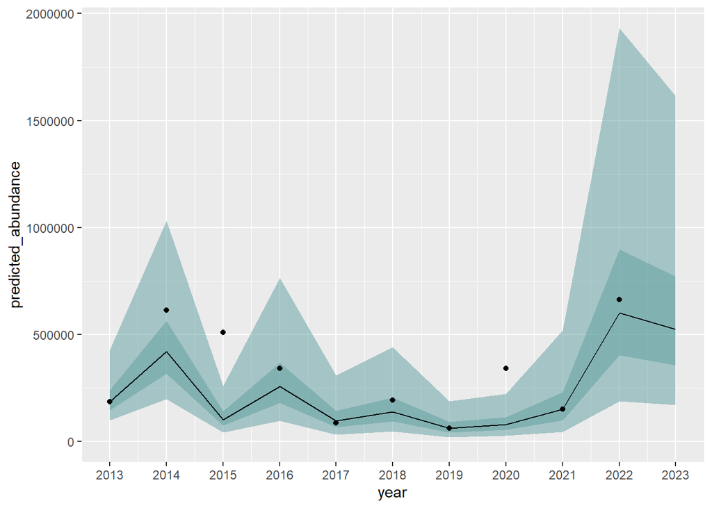

```r
p<-ggplot(results_best,aes(x=year,y=predicted_abundance))+
  geom_ribbon(aes(ymin=`Lo 95`,ymax=`Hi 95`),color=NA,alpha=0.5,fill = "cadetblue")+
  geom_ribbon(aes(ymin=`Lo 50`,ymax=`Hi 50`),color=NA,alpha=0.5,fill = "cadetblue")+
  geom_line()+
  geom_point(aes(x=year,y=abundance))+
  ylim(0,NA)+
  scale_x_continuous(breaks=unique(results$year))

print(p)
```